# Predicting US Consumer Spending

Maureen Stolberg, CIPM

April 11, 2020

## Introduction

### What is Consumer Spending?

Consumer spending is the total money spent on final goods and services by individuals and households for personal use and enjoyment in an economy. - Investopedia

Consumer spending is what households buy to fulfill everyday needs. Every one of us is a consumer. The things we buy every day create the demand that keeps the economy profitable and US labor force employed.

### Determinants of Consumer Spending:

There are four determinants of Consumer Spending; disposable income, personal income per capita, consumer debt, and consumer confidence. These are things that affect how much your spend. Changes in any of these components will affect consumer spending.

Disposable Income: Disposable income is the average income minus taxes and is one of the most important determinant of demand. As income increases so does demand. IF demand increases, worker’s wages rise, creating more spending-hence it’s a virtuous cycle that leads to ongoing economic expansion.

Personal Income Per Capita: Personal income per capita tells us how much each person has to spend. Income per person reveals whether a person’s standard of living is also improving.

Consumer Debt: Consumer debt includes credit card debt, auto loans, and school loans. The greater level of consumer debt, the greater percentage of income is used to make load payments, the smaller percentage of income is available for consumers to spend on personal consumption expenditures.

Consumer Confidence: Consumer confidence proxied via the consumer confidence index helps us guage consumer expectations. If people are confident, they are more likely to spend now vs. later.

### Why do we care about Consumer Spending?

Consumer spending drives GDP and is the single most important driving force of the US economy. Because consumer spending drives a significantly large part of the US GDP, it is also one of the biggest determinants of economic health. Understanding what consumers buy, don’t buy, or wish to spend their money can tell us a lot of where the economy is currently and where it is heading in the near future.

### How is Consumer Spending Measured?

Consumer spending is measured in several ways. The most comprehensive way is the monthly personal consumption expenditures report that is released by the Bureau of Labor Statistics.

For the purposes of this study, we will use the quarterly times series provided by the St. Louis Federal Reserve Economics Database. Please find the details listed below:

### Dataset Description

**Data Source:** St. Louis Federal Economic Database  
**Time Period:** January 1, 1990 - September 30, 2019  
**Interval:** Quarterly  
**Measurement:** Percentage Change from prior period  
**Response Variable:** U.S. Personal Consumption  
**Explanatory Variables:** Disposable Personal Income, Personal Income per Capita, Total Consumer Dect, Consumer Confidence Index

## Exploratory Data Analysis Section

Realization Plots of Response Variable: US Consumption

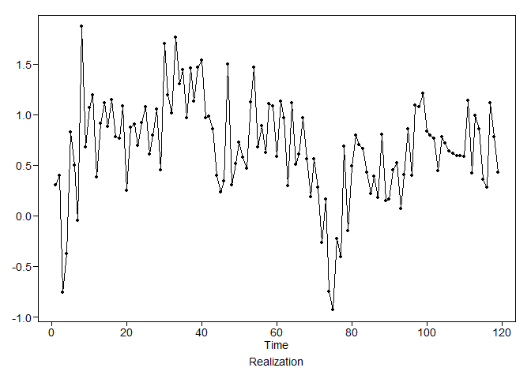

```r
plotts.wge(x)
```

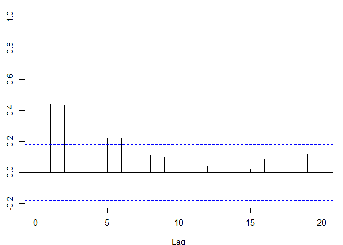

```r
acf(x)
```

Stationarity Condition 3 Plots  
First Half of Data: ACF Plot & Mean Estimate

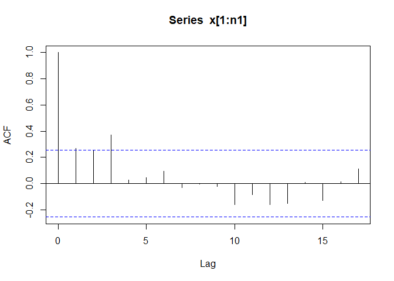

```r
acf(x[1:n1])
```

```r
mean(x[1:n1])
```

```
## [1] 0.8502205
```

Second Half of Data: ACF Plot & Mean Estimate

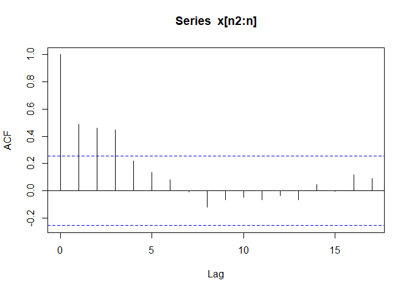

```r
acf(x[n2:n])
```

```r
mean(x[n2:n])
```

```
## [1] 0.5132998
```

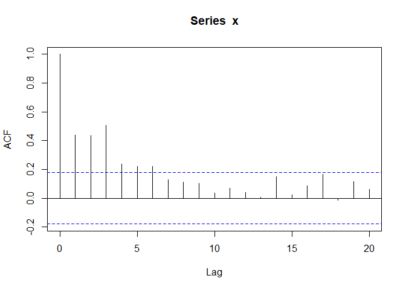

```r
acf(x)
```

## **Model Selection Analysis**

### **ARIMA Model**

Step 1: Difference the data to stationarize the time series

##### Differenced Data Time Realization Plots

```r
d1.x= artrans.wge(x, phi.tr=1)
```

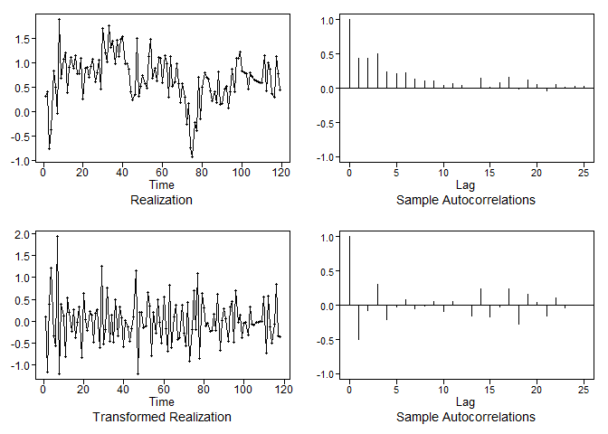

Check the acf’s to confirm that data looks stationary:

##### First Half of Differenced Data: ACF Plot & Mean Estimate

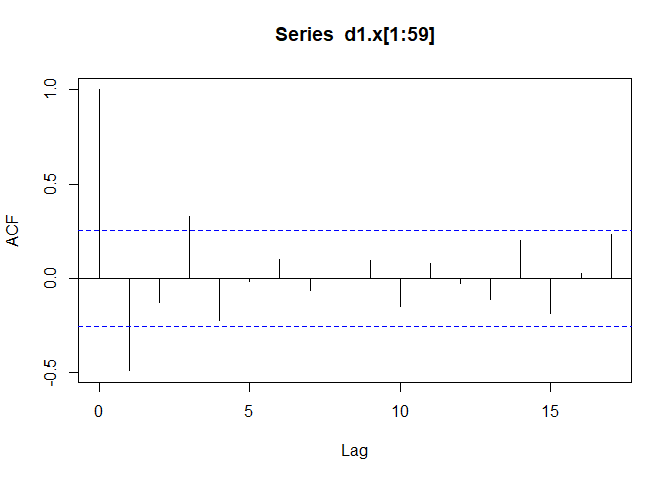

```r
#Determine length in order to recieve conditional ACF plots
dn <- length(d1.x)
dn1 <- dn/2
dn2 <- dn/2+1

#1st Half dACF
acf(d1.x[1:59])
```

```r
mean(d1.x[1:59])
```

```
## [1] 0.004733898
```

##### Second Half of Differenced Data: ACF Plot & Mean Estimate

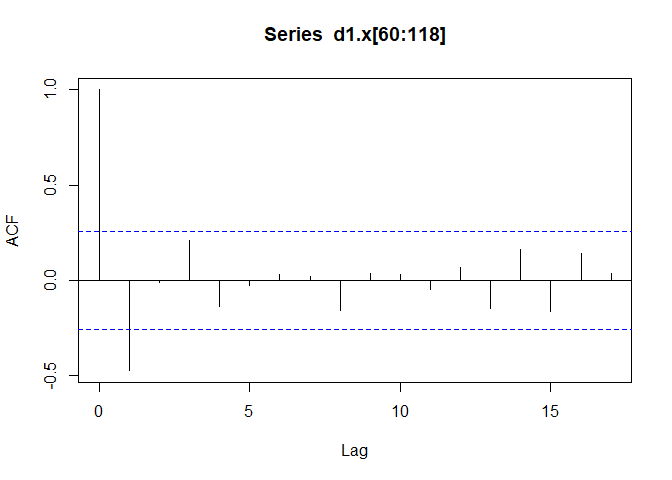

```r
#2nd Half dACF
acf(d1.x[60:118])
```

```r
mean(d1.x[60:118])
```

```
## [1] -0.002632034
```

Now that data appears stationary, run AIC5 to determine optimal P&Q based on AIC & BIC

##### AIC5 results for AIC measure:

```r
aic5.wge(d1.x, p=0:5, q=0:2)
```

```
## ---------WORKING... PLEASE WAIT...
##
##
## Five Smallest Values of  aic
```

```
##       p    q        aic
## 7     2    0  -1.754901
## 10    3    0  -1.740978
## 8     2    1  -1.740405
## 9     2    2  -1.731115
## 13    4    0  -1.725735
```

##### AIC5 results for BIC measure:

```r
aic5.wge(d1.x, p=0:5, q=0:2, type="bic")
```

```
## ---------WORKING... PLEASE WAIT...
##
##
## Five Smallest Values of  bic
```

```
##       p    q        bic
## 7     2    0  -1.684460
## 10    3    0  -1.647057
## 8     2    1  -1.646484
## 2     0    1  -1.629685
## 9     2    2  -1.613713
```

Based on AIC results-we will estimate parameters (using Burg) to fit an ARIMA Model(2,1,0) and an ARIMA Model (3,1,0) Model based on differenced data.

### ARIMA Model (2,1,0)

##### Parameter Estimates

```r
AR2 = est.ar.wge(d1.x, p=2, type='burg')
```

```
##
## Coefficients of Original polynomial:
## -0.7146 -0.4465
##
## Factor                 Roots                Abs Recip    System Freq
## 1+0.7146B+0.4465B^2   -0.8003+-1.2647i      0.6682       0.3398
##
##
```

```r
mean(x)
```

```
## [1] 0.679633
```

#### Final ARIMA Model (2,1,0) Equation:

$$(1-B) (1+ 0.715B + 0.447B^2)(X_t - 0.6796)=a_{t}$$
$$ð^2_{a}=0.164$$

Now that we have fit the model-lets run check residuals for white noise before proceed any further.

#### Residual Checks:

Step 1: Lets looks at the residuals to see if they visually to see if behavior resembles white noise:

##### Visual Check of Residual Sample Correlations

Residual sample correlations appear to be w/in 95% limit lines.

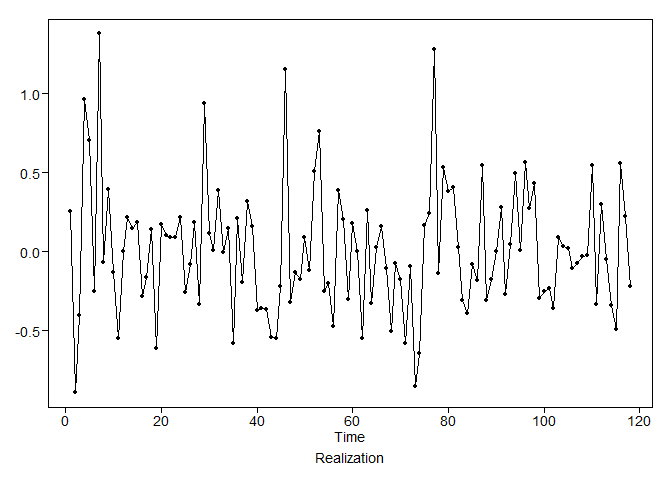

```r
plotts.wge(AR2$res)
```

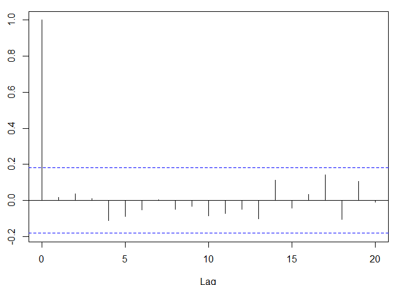

```r
acf(AR2$res)
```

Residual sample correlations appear to be w/in 95% limit lines.

Step 2: Let’s run the lJung-Box test for k=24 to determine the significance

##### Ljung-Box test for k=24

L Jung Box Test did not reject the null hypothesis of white noise at K=24 with pvalue of .73.

```r
ljung.wge(AR2$res,p=2)
```

```
## Obs 0.01610608 0.03641318 0.01036577 -0.1103464 -0.08664022 -0.05197618 0.003450041 -0.0494592 -0.03120141 -0.08537762 -0.07160215 -0.04683308 -0.101942 0.1142823 -0.04276233 0.03328682 0.1427831 -0.1038486 0.1045336 -0.01034202 -0.1037039 0.005355593 -0.0185757 0.08576376
```

```
## $test
## [1] "Ljung-Box test"
##
## $K
## [1] 24
##
## $chi.square
## [1] 17.65336
##
## $df
## [1] 22
##
## $pval
## [1] 0.7263314
```

Step 3: Let’s run the lJung-Box test for k=48 to determine the significance

##### Ljung-Box test for k=48

L Jung Box Test did not reject the null hypothesis of white noise at K=48 with pvalue of .42.

```r
ljung.wge(AR2$res,p=2,K=48)
```

```
## Obs 0.01610608 0.03641318 0.01036577 -0.1103464 -0.08664022 -0.05197618 0.003450041 -0.0494592 -0.03120141 -0.08537762 -0.07160215 -0.04683308 -0.101942 0.1142823 -0.04276233 0.03328682 0.1427831 -0.1038486 0.1045336 -0.01034202 -0.1037039 0.005355593 -0.0185757 0.08576376 0.03377424 0.01834254 -…
```

```
## $test
## [1] "Ljung-Box test"
##
## $K
## [1] 48
##
## $chi.square
## [1] 47.18405
##
## $df
## [1] 46
##
## $pval
## [1] 0.4239373
```

#### Conclusion of Residual Checks:

Based on the visual sample correlation plots and the L Jung-Box Tests, the residuals from the fitted model appear to be white.

### Forecast using ARIMA Model(2,1,0)

```r
phi <- AR2$phi
vara <- AR2$avar
d <- 1
fAR2 =fore.aruma.wge(x, phi=phi, d=d, n.ahead=8,limits=FALSE)
```

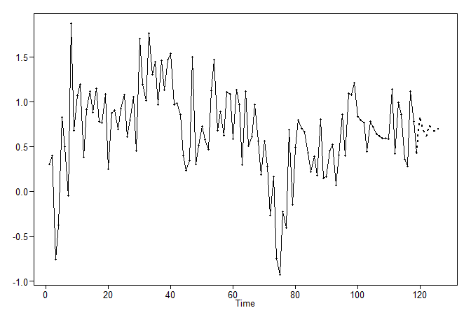

```r
f2=fore.aruma.wge(x, phi=phi,d=d, n.ahead=8,limits=TRUE)
```

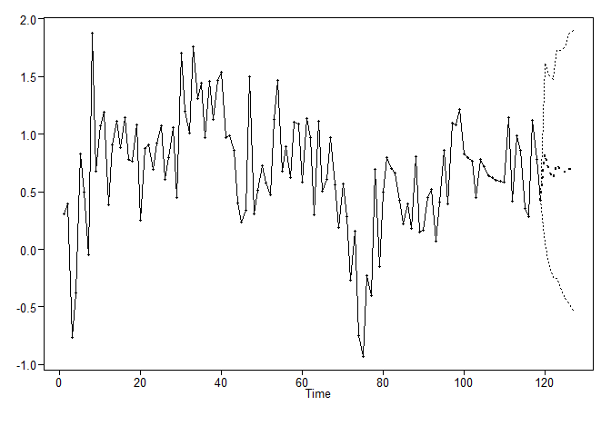

```r
fAR2
```

```
## $f
## [1] 0.8309561 0.6996071 0.6138414 0.7337716 0.6863628 0.6666954 0.7019160
## [8] 0.6855287
##
## $ll
## [1]  0.04716341 -0.11548477 -0.24607101 -0.25502111 -0.35068372 -0.42542714
## [7] -0.46098101 -0.52758713
##
## $ul
## [1] 1.614749 1.514699 1.473754 1.722564 1.723409 1.758818 1.864813 1.898645
##
## $resid
##   [1]  0.000000000  0.000000000  0.000000000 -0.401476866  0.963845720
##   [6]  0.703322477 -0.247686598  1.383067318 -0.064794053  0.398617198
##  [11] -0.131951786 -0.547236655  0.001538200  0.218783577  0.146440508
##  [16]  0.188189468 -0.282159611 -0.158116363  0.145751779 -0.611179916
##  [21]  0.174244127  0.106791479  0.092471289  0.089051941  0.219456666
##  [26] -0.258937873 -0.076984113  0.184928710 -0.334901945  0.937702382
##  [31]  0.117361902  0.011652809  0.390613039 -0.002155276  0.149062322
##  [36] -0.579007546  0.211705302 -0.191978218  0.319224402  0.163841571
##  [41] -0.369119764 -0.360461321 -0.364599132 -0.539322614 -0.546681560
##  [46] -0.217009954  1.155305023 -0.317624015 -0.127858524 -0.171678496
##  [51]  0.093294377 -0.116944393  0.512157674  0.763548266 -0.252576339
##  [56] -0.198187135 -0.468402324  0.387103731  0.207070566 -0.300667770
##  [61]  0.182608344  0.004895781 -0.544614823  0.262577033 -0.323945674
##  [66]  0.030527068  0.161489468 -0.105814039 -0.504651730 -0.071447855
##  [71] -0.176025209 -0.580161807 -0.090978337 -0.850428096 -0.642234839
##  [76]  0.168621207  0.243059438  1.281742762 -0.135469688  0.533103884
##  [81]  0.385105924  0.405774148  0.027781991 -0.305318951 -0.389904946
##  [86] -0.081083512 -0.178806547  0.548078667 -0.305656645 -0.175750228
##  [91]  0.003954591  0.280893239 -0.269994215  0.046882241  0.494667729
##  [96]  0.008038844  0.568820038  0.273728972  0.435791043 -0.292134357
## [101] -0.247651913 -0.228141381 -0.354471483  0.093961430  0.034412858
## [106]  0.022984662 -0.103476326 -0.072866347 -0.026027117 -0.019376411
## [111]  0.546719191 -0.330386612  0.301835532 -0.045957201 -0.339311259
## [116] -0.489863127  0.560721034  0.223618364 -0.220115554
##
## $wnv
## [1] 0.1599154
##
## $se
## [1] 0.3998942 0.4158632 0.4387308 0.5044861 0.5291054 0.5572054 0.5933148
## [8] 0.6189366
##
## $psi
## [1] 0.2854133 0.3495789 0.6227675 0.3989026 0.4369034 0.5096972 0.4407136
## [8] 0.4575082
##
## $ptot
## [1] 3
##
## $phitot
## [1] 0.2854133 0.2681182 0.4464685
```

#### ASE for ARIMA Model (2,1,0) Forecast

```r
#Determine ASE
ARIMA_210.ASE = mean((x[112:119] - fAR2$f)^2)
ARIMA_210.ASE
```

```
## [1] 0.1119084
```

#### Compare ARIMA Model (2,1,0) forecast to Realizations

#### Compare Spectral Densities

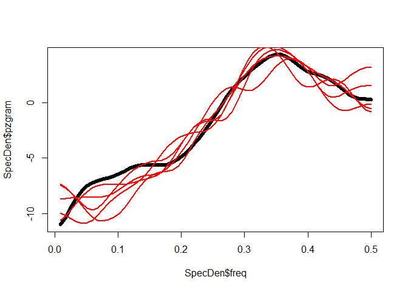

```r
sims = 5
SpecDen = parzen.wge(d1.x, plot = "FALSE")
plot(SpecDen$freq,SpecDen$pzgram, type = "l", lwd = 6)

for( i in 1: sims)
{
  SpecDen2 = parzen.wge(gen.arma.wge(118, phi=phi, plot = "FALSE"), plot = "FALSE")
  lines(SpecDen2$freq,SpecDen2$pzgram, lwd = 2, col = "red")
}
```

#### Compare Acf’s

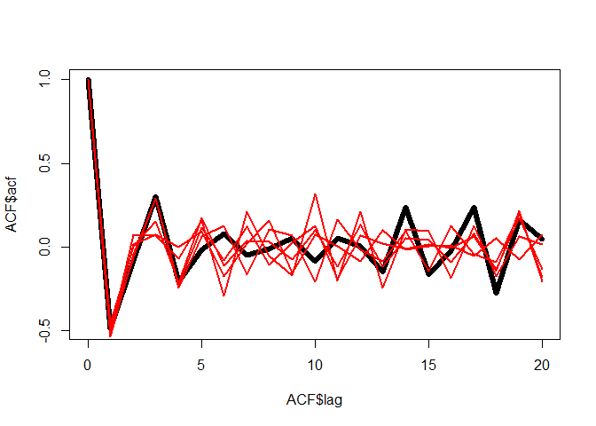

```r
sims = 5
ACF = acf(d1.x, plot = "FALSE")
plot(ACF$lag ,ACF$acf , type = "l", lwd = 6)

for( i in 1: sims)
{
  ACF2 = acf(gen.arma.wge(118, phi = phi, plot ="FALSE"), plot = "FALSE")
  lines(ACF2$lag ,ACF2$acf, lwd = 2, col = "red")
}
```

#### Compare Generated Realizations

```r
AR2.gen = gen.arma.wge(119, phi =phi, vara = vara)
```

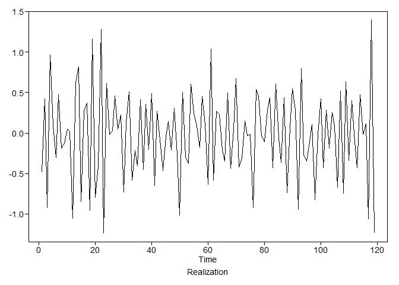

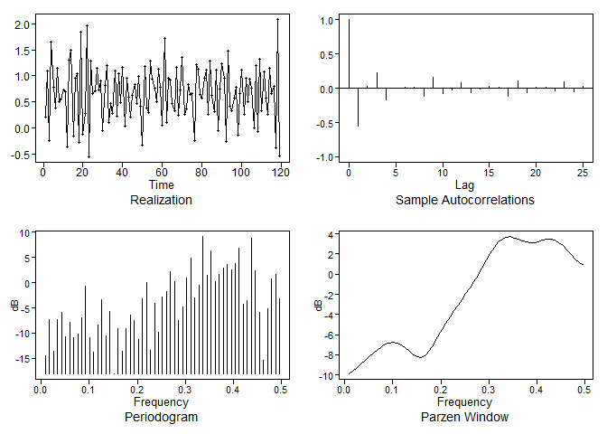

[output not shown]

[output cut: 34 more lines]

```r
plotts.sample.wge(AR2.gen + mean(x))
```

### **ARIMA Model (3,1,0)**

##### Parameter Estimates

```r
AR3 = est.ar.wge(d1.x, p=3, type='burg')
```

```
##
## Coefficients of Original polynomial:
## -0.6899 -0.4069 0.0553
##
## Factor                 Roots                Abs Recip    System Freq
## 1+0.8014B+0.4963B^2   -0.8074+-1.1675i      0.7045       0.3463
## 1-0.1115B              8.9672               0.1115       0.0000
##
##
```

```r
mean(x)
```

```
## [1] 0.679633
```

Now that we have fit the model-lets run check residuals for white noise before proceed any further.

#### Residual Checks:

Step 1: Lets looks at the residuals to see if they visually look ok:

##### Visual Check of Residual Sample Correlations

Residual sample correlations appear to be w/in 95% limit lines.

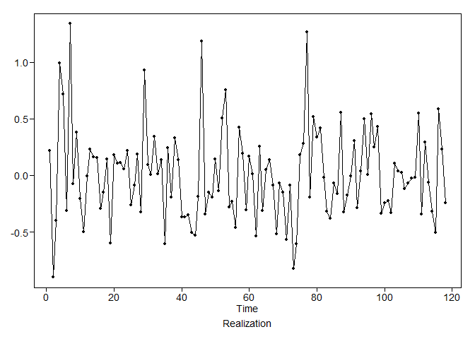

```r
plotts.wge(AR3$res)
```

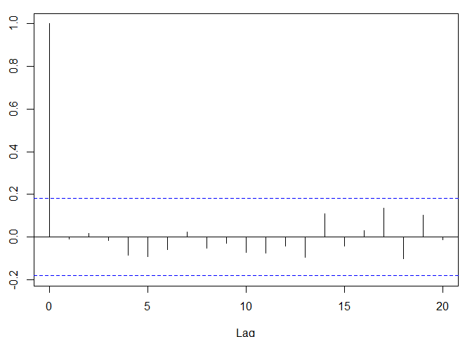

```r
acf(AR3$res)
```

Residual sample correlations appear to be w/in 95% limit lines.

Step 2: Let’s run the lJung-Box test for k=24 to determine the significance

##### Ljung-Box test for k=24

L Jung Box Test did not reject the null hypothesis of white noise at K=24 with pvalue of .77.

```
## Obs -0.007962076 0.01817719 -0.0140725 -0.0830495 -0.0907199 -0.05693491 0.02371353 -0.051897 -0.02882004 -0.07030795 -0.07347304 -0.04176394 -0.09553553 0.1095981 -0.04065851 0.03162643 0.1346738 -0.1015942 0.1033961 -0.01145708 -0.09798718 -0.0004579605 -0.02055218 0.09213992
```

```
## $test
## [1] "Ljung-Box test"
##
## $K
## [1] 24
##
## $chi.square
## [1] 16.02033
##
## $df
## [1] 21
##
## $pval
## [1] 0.7685077
```

Step 3: Let’s run the lJung-Box test for k=48 to determine the significance

##### Ljung-Box test for k=48

L Jung Box Test did not reject the null hypothesis of white noise at K=48 with pvalue of .47.

```r
ljung.wge(AR3$res,p=3,K=48)
```

```
## Obs -0.007962076 0.01817719 -0.0140725 -0.0830495 -0.0907199 -0.05693491 0.02371353 -0.051897 -0.02882004 -0.07030795 -0.07347304 -0.04176394 -0.09553553 0.1095981 -0.04065851 0.03162643 0.1346738 -0.1015942 0.1033961 -0.01145708 -0.09798718 -0.0004579605 -0.02055218 0.09213992 0.03099567 0.01376…
```

```
## $test
## [1] "Ljung-Box test"
##
## $K
## [1] 48
##
## $chi.square
## [1] 45.15487
##
## $df
## [1] 45
##
## $pval
## [1] 0.465482
```

#### Conclusion of Residual Checks:

Based on the visual sample correlation plots and the L Jung-Box Tests, the residuals from the fitted model appear to be white.

### Forecast using ARIMA Model(3,1,0)

```r
phi <- AR3$phi
vara <- AR3$avar
d <- 1
fAR3 =fore.aruma.wge(x, phi=phi, d=d, n.ahead=8,limits=FALSE)
```

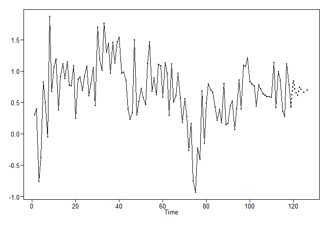

```r
f2AR3=fore.aruma.wge(x, phi=phi,d=d, n.ahead=8,limits=TRUE)
```

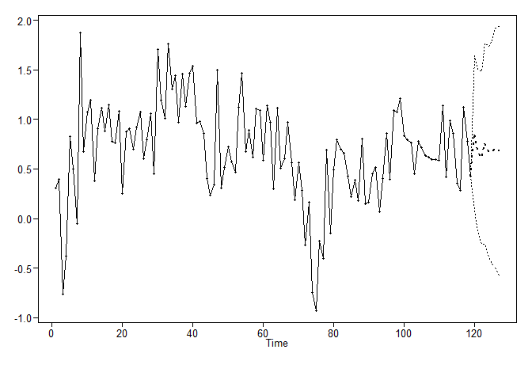

```r
fAR3
```

```
## $f
## [1] 0.8551202 0.6843181 0.6092469 0.7541436 0.6752776 0.6665693 0.7126884
## [8] 0.6800506
##
## $ll
## [1]  0.07257186 -0.13499788 -0.26213346 -0.26184428 -0.38837495 -0.45933114
## [7] -0.49205156 -0.57562944
##
## $ul
## [1] 1.637669 1.503634 1.480627 1.770132 1.738930 1.792470 1.917428 1.935731
##
## $resid
##   [1]  0.000000000  0.000000000  0.000000000  0.000000000  0.995038145
##   [6]  0.722417166 -0.308535953  1.342985097 -0.072289389  0.382479393
##  [11] -0.200906432 -0.499675847 -0.004982860  0.231116401  0.165358920
##  [16]  0.156808149 -0.290731623 -0.146555441  0.145968375 -0.598228374
##  [21]  0.182981169  0.106564892  0.113028158  0.058311504  0.220477440
##  [26] -0.260005093 -0.083886747  0.190334837 -0.322877311  0.931918401
##  [31]  0.095966124  0.008074504  0.345896090  0.014788271  0.140879481
##  [36] -0.605941454  0.243136490 -0.192995397  0.334334403  0.141486032
##  [41] -0.365939323 -0.367779287 -0.346352443 -0.505400372 -0.531372855
##  [46] -0.188077967  1.184627338 -0.341203375 -0.149932560 -0.193596505
##  [51]  0.145689704 -0.133038994  0.508967319  0.759820126 -0.281137871
##  [56] -0.228414529 -0.461422679  0.429002721  0.193942039 -0.304495324
##  [61]  0.169020769  0.012232685 -0.534493726  0.255226172 -0.308431944
##  [66]  0.050484775  0.137826587 -0.085084277 -0.514361791 -0.066047346
##  [71] -0.147969041 -0.567516416 -0.087289256 -0.823775219 -0.606206741
##  [76]  0.185514343  0.283202259  1.268384711 -0.194463280  0.520427892
##  [81]  0.341749661  0.419313489 -0.017297450 -0.317198661 -0.377301227
##  [86] -0.064614203 -0.161880813  0.557835002 -0.322168961 -0.172533727
##  [91] -0.004873930  0.309535436 -0.283890215  0.039367952  0.500214938
##  [96]  0.008295326  0.543803292  0.249740425  0.434397332 -0.333503513
## [101] -0.242633733 -0.219703129 -0.331142020  0.105010970  0.040424728
## [106]  0.028807188 -0.117450353 -0.065736983 -0.020261919 -0.017427400
## [111]  0.548293381 -0.343684197  0.298249092 -0.062107457 -0.318685674
## [116] -0.503894524  0.589606236  0.233539293 -0.240691187
##
## $wnv
## [1] 0.1594081
##
## $se
## [1] 0.3992594 0.4180183 0.4445818 0.5183612 0.5426799 0.5744390 0.6146632
## [8] 0.6406531
##
## $psi
## [1] 0.3101230 0.3791334 0.6675943 0.4023289 0.4717683 0.5477702 0.4524009
## [8] 0.4911104
##
## $ptot
## [1] 4
##
## $phitot
## [1]  0.3101230  0.2829571  0.4622647 -0.0553449
```

#### ASE for ARIMA Model (3,1,0) Forecast

```r
ARIMA_310.ASE = mean((x[112:119] - fAR3$f)^2)
ARIMA_310.ASE
```

```
## [1] 0.1162381
```

#### Compare ARIMA Model (3,1,0) forecast to Realizations

#### Compare Spectral Densities

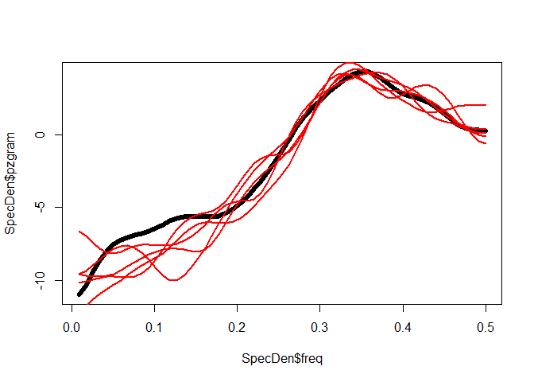

```r
phi <- AR3$phi
vara <- AR3$avar
d <- 1

sims = 5
SpecDen = parzen.wge(d1.x, plot = "FALSE")
plot(SpecDen$freq,SpecDen$pzgram, type = "l", lwd = 6)

for( i in 1: sims)
{
  SpecDen2 = parzen.wge(gen.arma.wge(118, phi=phi, plot = "FALSE"), plot = "FALSE")
  lines(SpecDen2$freq,SpecDen2$pzgram, lwd = 2, col = "red")
}
```

#### Compare Acf’s

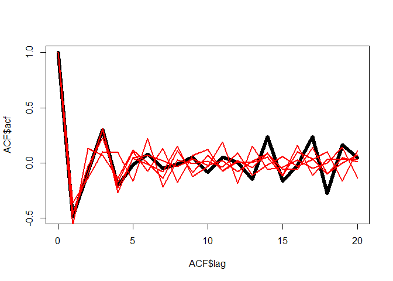

```r
sims = 5
ACF = acf(d1.x, plot = "FALSE")
plot(ACF$lag ,ACF$acf , type = "l", lwd = 6)

for( i in 1: sims)
{
  ACF3 = acf(gen.arma.wge(119, phi = phi, plot ="FALSE"), plot = "FALSE")
  lines(ACF3$lag ,ACF3$acf, lwd = 2, col = "red")
}
```

#### Compare Generated Realizations

```r
AR3.gen = gen.arma.wge(119, phi =phi, vara = vara)
```

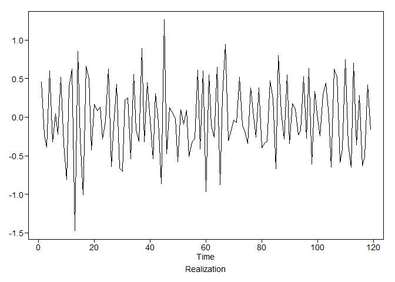

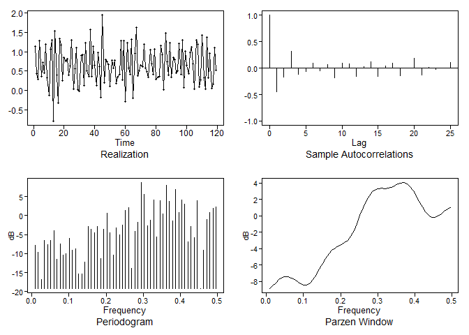

[output not shown]

[output cut: 34 more lines]

```r
plotts.sample.wge(AR3.gen + mean(x))
```

### **VAR Models**

We will look at two different VAR models; one basic model and one model that looks at differenced data for each of the underlying variables.

Variables include: US Consumption, Disposable Income, Personal Income per Capita, Consumer Debt, and Consumer Confidence. We will use the first 111 data points to model the data and the last 8 data points to check our forecasts.

A VAR model is a generalisation of the univariate autoregressive model for forecasting a vector of time series. VAR enables us to simultaneously model several time series at once.

#### **Model 1: Basic VAR Model (Var1)**

Step 1: Combine variables into one dataset and run VarSelect function to determine the optimal number of lags that should be used for the Master VAR Model.

```r
# VAR and VARselect are from CRAN package vars
X=cbind(x1, x2, x3, x4, x5)
VARselect(X, lag.max = 8, type = "const", season =NULL, exogen = NULL)
```

```
## $selection
## AIC(n)  HQ(n)  SC(n) FPE(n)
##      3      1      1      2
##
## $criteria
##                    1             2             3             4
## AIC(n) -7.7662266337 -7.9583818604 -7.9645983960 -7.9035911151
## HQ(n)  -7.4554046571 -7.3885415698 -7.1357397916 -6.8157141968
## SC(n)  -6.9988298410 -6.5514877404 -5.9182069488 -5.2177023407
## FPE(n)  0.0004240894  0.0003511512  0.0003519859  0.0003802755
##                    5             6             7             8
## AIC(n) -7.9307153375 -7.6954596892 -7.5219654765 -7.5004835044
## HQ(n)  -6.5838201053 -6.0895461432 -5.6570336165 -5.3765333306
## SC(n)  -4.6053292358 -3.7305762603 -2.9175847203 -2.2566054210
## FPE(n)  0.0003801471  0.0005008019  0.0006310001  0.0006977348
```

The function VARSelect identified the VAR model as a VAR(3). This is consistent with known previously published literature concerning popular lags used for predicting US consumption. Lets proceed to step 2.

#### Basic VAR Model Prediction Summary

```r
#VARselect picks p=3 (using AIC)
lsfit=VAR(X, p=4 ,type="const")
summary(lsfit)
```

```
##
## VAR Estimation Results:
## =========================
## Endogenous variables: x1, x2, x3, x4, x5
## Deterministic variables: const
## Sample size: 107
## Log Likelihood: -239.844
## Roots of the characteristic polynomial:
## 0.8645 0.7825 0.7825 0.7756 0.7756 0.7688 0.7688 0.6879 0.6879 0.6795 0.6795 0.633 0.633 0.5395 0.5395 0.5324 0.4717 0.4717 0.3685 0.3685
## Call:
## VAR(y = X, p = 4, type = "const")
##
##
## Estimation results for equation x1:
## ===================================
## x1 = x1.l1 + x2.l1 + x3.l1 + x4.l1 + x5.l1 + x1.l2 + x2.l2 + x3.l2 + x4.l2 + x5.l2 + x1.l3 + x2.l3 + x3.l3 + x4.l3 + x5.l3 + x1.l4 + x2.l4 + x3.l4 + x4.l4 + x5.l4 + const
##
##        Estimate Std. Error t value Pr(>|t|)
## x1.l1  0.162729   0.114187   1.425  0.15774
## x2.l1  0.193120   0.074758   2.583  0.01148 *
## x3.l1 -0.155567   0.075027  -2.073  0.04112 *
## x4.l1 -0.054909   0.045375  -1.210  0.22955
## x5.l1 -0.031336   0.369264  -0.085  0.93257
## x1.l2  0.339916   0.106209   3.200  0.00192 **
## x2.l2  0.033315   0.077578   0.429  0.66867
## x3.l2 -0.083892   0.076253  -1.100  0.27433
## x4.l2 -0.014164   0.046008  -0.308  0.75894
## x5.l2  0.198021   0.356272   0.556  0.57978
## x1.l3  0.478210   0.111257   4.298 4.52e-05 ***
## x2.l3 -0.075070   0.077475  -0.969  0.33528
## x3.l3  0.016404   0.075110   0.218  0.82764
## x4.l3  0.017411   0.044745   0.389  0.69815
## x5.l3  0.589366   0.357636   1.648  0.10301
## x1.l4 -0.094014   0.120824  -0.778  0.43865
## x2.l4 -0.060414   0.071267  -0.848  0.39895
## x3.l4 -0.036540   0.071101  -0.514  0.60862
## x4.l4  0.004998   0.042550   0.117  0.90678
## x5.l4  0.325071   0.351773   0.924  0.35802
## const  0.332898   0.090532   3.677  0.00041 ***
## ---
```

[output cut: 149 more lines]

```
## Covariance matrix of residuals:
##           x1        x2      x3       x4       x5
## x1  0.142633  0.058016 0.07650 -0.03888 0.008872
## x2  0.058016  0.503755 0.34516 -0.03471 0.007783
## x3  0.076496  0.345163 0.54651  0.06309 0.014800
## x4 -0.038883 -0.034711 0.06309  0.84489 0.014096
## x5  0.008872  0.007783 0.01480  0.01410 0.012029
##
## Correlation matrix of residuals:
##         x1       x2      x3       x4      x5
## x1  1.0000  0.21643 0.27399 -0.11201 0.21418
## x2  0.2164  1.00000 0.65783 -0.05321 0.09998
## x3  0.2740  0.65783 1.00000  0.09285 0.18253
## x4 -0.1120 -0.05321 0.09285  1.00000 0.13982
## x5  0.2142  0.09998 0.18253  0.13982 1.00000
```

```r
preds=predict(lsfit,n.ahead=8)
```

Final Model:

x1 = x1.l1 + x2.l1 + x3.l1 + x4.l1 + x5.l1 + x1.l2 + x2.l2 + x3.l2 + x4.l2 + x5.l2 + x1.l3 + x2.l3 + x3.l3 + x4.l3 + x5.l3 + x1.l4 + x2.l4 + x3.l4 + x4.l4 + x5.l4 + const

X= 0.162729x1.l1 + 0.193120x2.l1 -0.155567x3.l1 -0.054909x4.l1 -0.031336x5.l1 + 0.339916x1.l2 + 0.033315x2.l2 -0.083892x3.l2 -0.014164x4.l2 + 0.198021x5.l2 + 0.478210x1.l3 -0.075070x2.l3 + 0.016404x3.l3 + 0.0174114.l3 + 0.589366x5.l3 -0.094014x1.l4 -0.060414x2.l4 -0.036540x3.l4 + 0.004998x4.l4 + 0.325071x5.l4 + 0.332898const

Step 3: Plot the Prediction outcomes using the forecasted value, upper and lower confidence intervals. Predictions based on variable interactions that have significant value will show tighter confidence intervals. Predictions based on variables that may only have a slight dependance on each other will have wider confidence intervals.

#### Basic VAR Model Prediction Plot

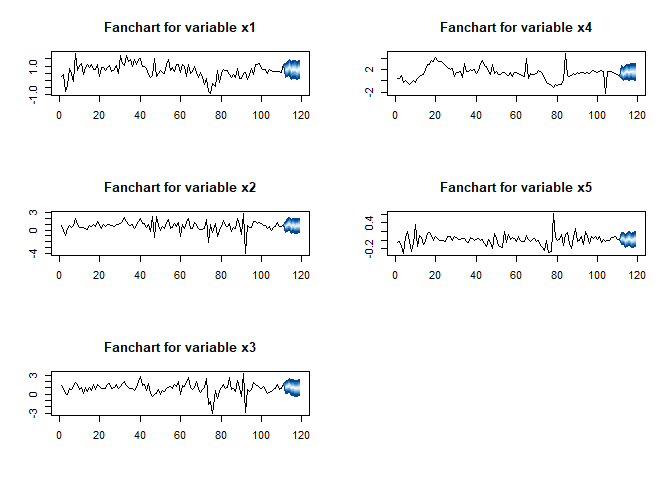

```r
#Plot prediction
fanchart(preds, colors = brewer.pal(n = 8, name = "Blues"))
```

#### Basic VAR Model Forecast: Predicted quarterly changes to US Consumption

```r
#to access predict results
preds$fcst$x1[1:8,1]
```

```
## [1] 0.6906306 0.7682899 0.9276665 0.7073603 0.7776984 0.7775994 0.6868755
## [8] 0.7730710
```

#### Basic VAR Model ASE Score

```r
#Calculate ASE for X
VAR1.ASE = mean((x_test[112:119] - preds$fcst$x1[,1])^2)
VAR1.ASE
```

```
## [1] 0.09246373
```

#### Basic VAR Model: Visual Comparisons of Predicted vs. Actual Time Series

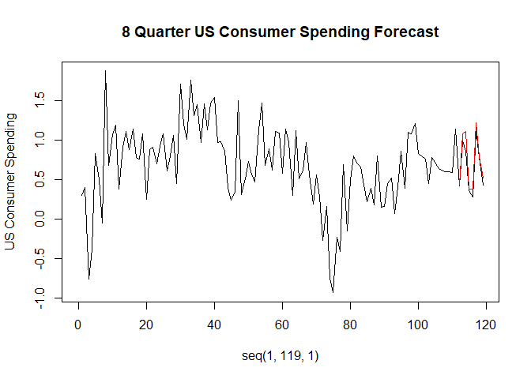

```r
#We have predicted differences .... calculate actual results
startingPoints = x_test[112:119]-(mean(x))
USConsumption_Forecast1 = preds$fcst$x1[,1:4] + startingPoints

#Plot
plot(seq(1,119,1), x_test, type="l", xlim = c(0,119), ylab = "US Consumer Spending", main = "8 Quarter US Consumer Spending Forecast")
lines(seq(112,119,1), USConsumption_Forecast1[,1], type = "l", col = "red")
```

#### **(Differenced Data) VAR Model 2:**

Step 1: We begin by taking the differences of the data in order to make them stationary.

Step 2: Combine variables into one dataset and run VarSelect function to determine the optimal number of lags that should be used for the Master VAR Model

```r
dX=cbind(dx1, dx2, dx3, dx4, dx5)
VARselect(dX, lag.max = 7, type = "const",season = NULL, exogen = NULL)
```

```
## $selection
## AIC(n)  HQ(n)  SC(n) FPE(n)
##      4      2      1      4
##
## $criteria
##                   1            2            3           4             5
## AIC(n) -6.550063936 -6.904721860 -6.904634184 -7.17835770 -7.0403131629
## HQ(n)  -6.239241959 -6.334881570 -6.075775579 -6.09048078 -5.6934179307
## SC(n)  -5.782667143 -5.497827740 -4.858242736 -4.49246892 -3.7149270613
## FPE(n)  0.001430969  0.001007147  0.001015925  0.00078535  0.0009260799
##                   6            7
## AIC(n) -6.984677445 -6.922072094
## HQ(n)  -5.378763899 -5.057140234
## SC(n)  -3.019794016 -2.317691338
## FPE(n)  0.001019424  0.001149635
```

The function VARSelect identified the VAR model as a VAR(4). This is consistent with known previously published literature concerning popular lags used for predicting US consumption. Lets proceed to step 2.

#### (Differenced Data) VAR Model 2: Prediction Summary

```r
lsfitdX=VAR(dX,p=4,type="const")
summary(lsfitdX)
```

```
##
## VAR Estimation Results:
## =========================
## Endogenous variables: dx1, dx2, dx3, dx4, dx5
## Deterministic variables: const
## Sample size: 106
## Log Likelihood: -279.516
## Roots of the characteristic polynomial:
## 0.8272 0.8272 0.8111 0.8111 0.795 0.795  0.78  0.78 0.729 0.729 0.7151 0.7151 0.6866 0.6866 0.6545 0.6545 0.6326 0.6326 0.6146 0.6146
## Call:
## VAR(y = dX, p = 4, type = "const")
##
##
## Estimation results for equation dx1:
## ====================================
## dx1 = dx1.l1 + dx2.l1 + dx3.l1 + dx4.l1 + dx5.l1 + dx1.l2 + dx2.l2 + dx3.l2 + dx4.l2 + dx5.l2 + dx1.l3 + dx2.l3 + dx3.l3 + dx4.l3 + dx5.l3 + dx1.l4 + dx2.l4 + dx3.l4 + dx4.l4 + dx5.l4 + const
##
##         Estimate Std. Error t value Pr(>|t|)
## dx1.l1 -0.732491   0.112202  -6.528 4.61e-09 ***
## dx2.l1  0.147606   0.067735   2.179   0.0321 *
## dx3.l1 -0.073340   0.070248  -1.044   0.2994
## dx4.l1 -0.069226   0.042748  -1.619   0.1091
## dx5.l1  0.086573   0.330400   0.262   0.7939
## dx1.l2 -0.290503   0.147004  -1.976   0.0514 .
## dx2.l2  0.140739   0.089529   1.572   0.1197
## dx3.l2 -0.089059   0.084316  -1.056   0.2938
## dx4.l2 -0.098313   0.049269  -1.995   0.0492 *
## dx5.l2  0.122327   0.393991   0.310   0.7570
## dx1.l3  0.144378   0.145250   0.994   0.3230
## dx2.l3  0.013482   0.088930   0.152   0.8799
## dx3.l3  0.022811   0.077673   0.294   0.7697
## dx4.l3 -0.087596   0.049922  -1.755   0.0829 .
## dx5.l3  0.387504   0.394217   0.983   0.3284
## dx1.l4  0.006454   0.120725   0.053   0.9575
## dx2.l4 -0.068886   0.064568  -1.067   0.2891
## dx3.l4  0.051902   0.067009   0.775   0.4408
## dx4.l4 -0.074712   0.042141  -1.773   0.0798 .
## dx5.l4  0.273836   0.320724   0.854   0.3956
## const   0.013460   0.037914   0.355   0.7235
## ---
```

[output cut: 149 more lines]

```
## Covariance matrix of residuals:
##           dx1       dx2     dx3       dx4      dx5
## dx1  0.150864  0.060591 0.09802 -0.038481 0.008883
## dx2  0.060591  0.748273 0.51442 -0.005962 0.011362
## dx3  0.098020  0.514424 0.70789  0.137807 0.012774
## dx4 -0.038481 -0.005962 0.13781  0.908172 0.004273
## dx5  0.008883  0.011362 0.01277  0.004273 0.014184
##
## Correlation matrix of residuals:
##         dx1       dx2    dx3       dx4     dx5
## dx1  1.0000  0.180338 0.2999 -0.103961 0.19204
## dx2  0.1803  1.000000 0.7068 -0.007232 0.11029
## dx3  0.2999  0.706818 1.0000  0.171871 0.12748
## dx4 -0.1040 -0.007232 0.1719  1.000000 0.03765
## dx5  0.1920  0.110286 0.1275  0.037650 1.00000
```

```r
preds.dX=predict(lsfitdX,n.ahead=8)
```

Final Model for X1 (US Consumption): X = X.l1 + X2.l1 + X3.l1 + X4.l1 + X5.l1 + X.l2 + X2.l2 + X3.l2 + X4.l2 + X5.l2 + X.l3 + X2.l3 + X3.l3 + X4.l3 + X5.l3 + X.l4 + X2.l4 + X3.l4 + X4.l4 + X5.l4 + const

Step 5: Plot the Prediction outcomes using the forecasted value, upper and lower confidence intervals. Predictions based on variable interactions that have significant value will show tighter confidence intervals. Predictions based on variables that may only have a slight dependance on each other will have wider confidence intervals.

#### (Differenced Data) VAR Model 2: Prediction Plot

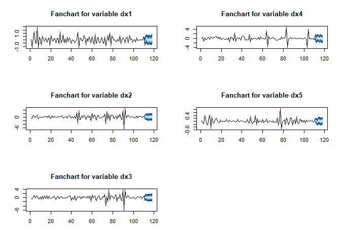

```r
fanchart(preds.dX, colors = brewer.pal(n = 8, name = "Blues"))
```

#### (Differenced Data) VAR Model 2: Predicted Time Series for US Consumption

```r
#to access predict results
preds.dX$fcst$dx1[1:8,1]
```

```
## [1] -0.38822515  0.13910355  0.15415132 -0.15775347  0.05077884  0.02473720
## [7] -0.09245594  0.10538987
```

#### (Differenced Data) VAR Model 2: ASE Score

```
## [1] 0.5306511
```

#### (Differenced Data) VAR Model 2: Visual Comparisons of Predicted vs. Actual Time Series

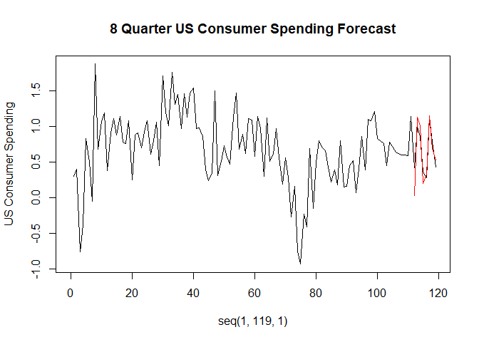

```r
#We have predicted differences .... calculate actual results
startingPoints = X_test
USConsumption_Forecast = preds.dX$fcst$dx1[,1:4] + startingPoints

#Plot
plot(seq(1,119,1), x_test, type="l", xlim = c(0,119), ylab = "US Consumer Spending", main = "8 Quarter US Consumer Spending Forecast")
lines(seq(112,119,1), USConsumption_Forecast[,1], type = "l", col = "red")
```

### **Neural Network Model**

We will look at 4 different Neural Network models; 2 univariate and 2 multivariate.

#### **Model 1: Univariate Default MLP Model**

Step 1: Run basic model for response variable only. Allow program to select parameter estimates. Run 100 reps.

##### Basic Neural Network (NN1) Model fit Summary

```r
#Create Training Set leaving last 4 variables to be used as comparison
X_train <- as.ts(EI$U.S.Consumption [1:111])
X_test <- EI$U.S.Consumption [112:119]
X1 <-as.ts(EI$DisponsableIncome[1:119])
X2<- as.ts(EI$ConsumerDebt[1:119])
X3 <- as.ts(EI$PersonalIncomePerCapita[1:119])
X4 <- as.ts(EI$ConsumerConfidenceIndex[1:119])
X_regressor <- data.frame(X1,X2,X3,X4)
set.seed(2)
```

##### Basic Neural Network (NN1) Model fit Summary

```r
fit.nn1 = mlp(X_train, reps = 100)
fit.nn1
```

```
## MLP fit with 5 hidden nodes and 100 repetitions.
## Univariate lags: (1,2,3,4)
## Forecast combined using the median operator.
## MSE: 0.0776.
```

#### Visual Diagram of Neural Network

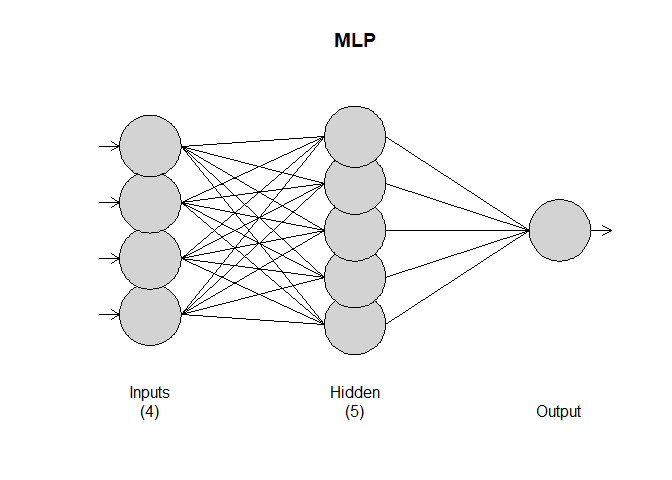

```r
plot(fit.nn1)
```

Step 2: Forecast the next 8 periods for the basic model (NN1) using parameters derived from model fit summary

#### NN1 Model Forecast Results & Visual Plot

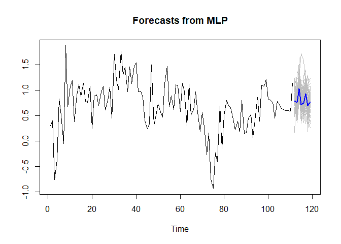

```r
fore.nn1 = forecast(fit.nn1, h=8)
plot(fore.nn1)
```

```r
fore.nn1
```

```
##     Point Forecast
## 112      0.7907437
## 113      0.7640166
## 114      1.0294439
## 115      0.7198469
## 116      0.7542611
## 117      0.9261030
## 118      0.6984838
## 119      0.7714334
```

Step 3: Compare forecasted datapoints to actual data points to visualize difference

##### NN1 Model Forecast Vs. Actual US Consumption Results

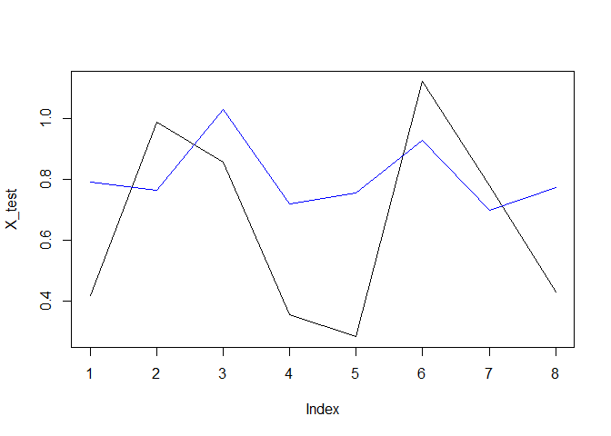

```r
plot(X_test, type="l")
lines(seq(1,8), fore.nn1$mean, col="blue")
```

Step 4: Calculate ASE for future comparison purposes:

#### ASE for (Basic Univariate) Neural Network Model 1:

```r
nn1.ASE = mean((X_test - fore.nn1$mean)^2)
nn1.ASE
```

```
## [1] 0.0918322
```

#### **Model 2: (Univariate Differenced) Neural Network Model 2**

Step 1: Run univariate MLP model using differenced data for response variable only. Allow program to select parameter estimates, except for difference order option. Run 100 reps.

##### Univariate set options- Neural Network (NN2) Model fit Summary

```r
fit.nn2 = mlp(X_train, difforder=c(1), reps = 100, allow.det.season = FALSE)
fit.nn2
```

```
## MLP fit with 5 hidden nodes and 100 repetitions.
## Series modelled in differences: D1.
## Univariate lags: (1,2)
## Forecast combined using the median operator.
## MSE: 0.1561.
```